# Another_view

## Data processing

```r
library(readxl)
library(dplyr)
library(ggplot2)
```

## Проблема № 1: что брать в качестве предиктора для описания климата

### Почему проблема

Климат описывается по многим параметрам большинство из них сильно коррелируют друг с другом. Если вставлять все эти параметры в одну модель, то коллинеарность между ними будет маскировать влияние друг относительно друга. Моедли построенные на такой матрице предиктоов будут иметь массу проблем (особенно если их использовать для пердсказаний).

### Как решать?

1. Возможно выбрать какой-то один параметр и считать его самым важным. Например, можно взять SWI и считать его единственным интересным параметром. Так можно, но, по-моему, неправильно терять информацию, например, по осадкам.
2. Поэтому предлагаю другой ход.

2. Выделяем PC, которые проходят по broken stick, как неслучайные.
3. Для каждой PC берем ту климатическйю метрику, которая имеет макисмальные нагрузки. Эти переменные и пойдут в дальнейший анализ в качестве предикторов.

Вот этот анализ

```r
clim <- read_excel("Data/bioclim.xlsx")

clim$Year <- as.numeric(clim$Year)

clim <-
  clim %>%
  filter(Year >= 2000)

library(vegan)

pca_clim <- rda(clim[,-1], scale = T)
```

Распределение собственных чисел

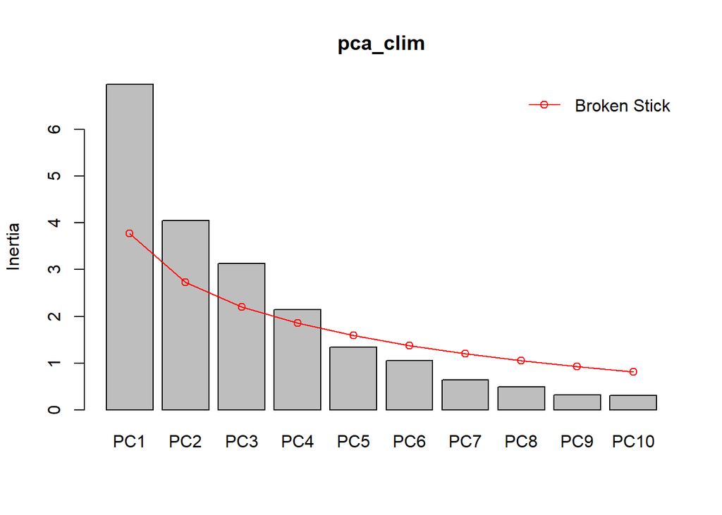

```r
screeplot(pca_clim, bstick = T)
```

Можно говорить про четыре главные компоненты

```r
PC_scores <- as.data.frame(scores(pca_clim, choices = 1:4)$species)
```

По первой PC максимальную связь имеет:

```r
PC_scores %>% filter(abs(PC1) == max(abs(PC1)))
```

```
##            PC1        PC2       PC3        PC4
## bio1 0.9306716 0.07819881 0.2299752 -0.1149712
```

По второй PC максимальную связь имеет:

```r
PC_scores %>% filter(abs(PC2) == max(abs(PC2)))
```

```
##             PC1       PC2       PC3        PC4
## bio13 0.2122988 0.7428405 -0.444687 -0.3468651
```

По третьей PC максимальную связь имеет:

```r
PC_scores %>% filter(abs(PC3) == max(abs(PC3)))
```

```
##              PC1       PC2       PC3        PC4
## bio3 -0.02475628 0.4511266 0.7374923 -0.2246988
```

По четвертой PC максимальную связь имеет:

```r
PC_scores %>% filter(abs(PC4) == max(abs(PC4)))
```

```
##           PC1        PC2        PC3        PC4
## bio5 0.639057 -0.2625472 -0.1937865 -0.6066056
```

Итак, вот кандидаты на то, чтобы войти в число неколлинеарных предикторов

- BIO1 = Annual Mean Temperature
- BIO13 = Precipitation of Wettest Month
- BIO3 = Isothermality (BIO2/BIO7) (×100)
- BIO5 = Max Temperature of Warmest Month

На всякий случай смотрим на корреляции между этими параметрами

```r
clim %>%
  select(bio1, bio13, bio3, bio5) %>%
  cor()
```

```
##            bio1      bio13        bio3       bio5
## bio1  1.0000000 0.17174990  0.10085571  0.5869647
## bio13 0.1717499 1.00000000  0.04894023  0.1766281
## bio3  0.1008557 0.04894023  1.00000000 -0.0867020
## bio5  0.5869647 0.17662807 -0.08670200  1.0000000
```

Есть высокая корреляция между BIO1 и BIO5, так что может из дальнейших построений BIO5 выкинем.

```r
clim_short <-
  clim %>%
  select(Year, bio1, bio13, bio3, bio5)
```

## Теперь про фенометрики

“Нам бы как-то единообразно все это сравнить - фенометрики с климатом, прирост деревьев с фенометриками, прирост деревьев с климатом…”

Если я правильно понимаю, то есть три датасета.

1. Климатические данные
2. Данные по феонометрикам
3. Данные по приросту деревьев. При этом на каждом сайте описан рост у нескольких видов.

Последние два датасета получены на 10 сайтах.

Все три матрицы надо как-то соединить в одном анализе.

Честно говоря, не понимаю, как такие данные можно обрабатывать без многомерных методов.

Но вот в качестве паллиатива предлагаю такой подход.

1. Из матрицы, содержащей данные по данной фенометрике делаем случайную выборку из 16 годов и 7 сайтов. Не спрашивайте, почему столько, просто это 2/3 от количества лет наблюдений и количества сайтов, соответственно. Приблизительно в такой пропорции режут на training data and testing data в парадигме cross validation. Короче, абсолютный произвол пока. Еще не додумал.
2. На основе полученных данных строим линейную модель вида

lm(Index ~ scale(bio1) + scale(bio13) + scale(bio3) , data = df)

`bio5` коллинеарит, так что выкинул.

**NB!** По-моему, модель должна быть смешанной, с “Plot” как случайный фактор. Если будем думать в этом направлении, то можно попробовать.

3. Записываем коэффициенты модели
4. Повторяем шаги 1-3, например, 1000 раз.
5. Строим частотное распределение коэффициентов модели
6. Очерчиваем интервал между 0.025 и 0.975 квантилями.
7. Смотрим попадает ли ноль в данный интервал.

Скорее всего, это все можно сделать каким-то стандартным пакетом под ресамплинг, но мне проще было написать самому. Возможно есть какие-то подводные камни, которые я не вижу.

Вот что получилось

```r
library(reshape2)

trees <- read_excel("Data/Фенология по сайтам реальных наблюдений/RWI_BAI.xlsx")

trees <-
  trees %>%
  filter(Species == "Picea_ajanensis")
```

```r
evi <-
  read.csv("Data/Фенология по сайтам реальных наблюдений/picea.gsdt.evi.csv") %>%
  select(sample.id, year, evi.max) %>%
  rename(Year = year) %>%
  filter(Year > 1999 & Year < 2024) %>%
  mutate(Plot = gsub(pattern = "S_", replacement = "", x = sample.id)) %>%
  select(-sample.id)

evi2 <-
  read.csv("Data/Фенология по сайтам реальных наблюдений/picea.gsdt.evi2.csv") %>%
  select(sample.id, year, evi2.max) %>%
  rename(Year = year) %>%
  filter(Year > 1999 & Year < 2024) %>%
  mutate(Plot = gsub(pattern = "S_", replacement = "", x = sample.id)) %>%
  select(-sample.id)


kndvi <-
  read.csv("Data/Фенология по сайтам реальных наблюдений/picea.gsdt.kndvi.csv") %>%
  select(sample.id, year, kndvi.max) %>%
  rename(Year = year) %>%
  filter(Year > 1999 & Year < 2024) %>%
  mutate(Plot = gsub(pattern = "S_", replacement = "", x = sample.id)) %>%
  select(-sample.id)

ndvi <-
  read.csv("Data/Фенология по сайтам реальных наблюдений/picea.gsdt.ndvi.csv") %>%
  select(sample.id, year, ndvi.max) %>%
  rename(Year = year) %>%
  filter(Year > 1999 & Year < 2024) %>%
  mutate(Plot = gsub(pattern = "S_", replacement = "", x = sample.id)) %>%
  select(-sample.id)


nirv <-
  read.csv("Data/Фенология по сайтам реальных наблюдений/picea.gsdt.nirv.csv") %>%
  select(sample.id, year, nirv.max) %>%
  rename(Year = year) %>%
  filter(Year > 1999 & Year < 2024) %>%
  mutate(Plot = gsub(pattern = "S_", replacement = "", x = sample.id)) %>%
  select(-sample.id)
```

```r
set.seed(12345)

resample_n <- 1000
year_num <- 16
site_num <- 7

years_full <- unique(clim$Year)

sites_full <- as.numeric(unique(evi$Plot))

######################
cors_evi <- data.frame(Index = rep("evi", resample_n))


for(i in 1:resample_n){

  years <- sample(years_full, size = year_num)
  Site <- sample(sites_full, size = site_num)


  x <-
    evi %>%
    filter(Plot %in% Site & Year %in% years)

  y <-
    clim_short %>%
    filter(Year %in% years)

  df <- merge(x, y, all.x = T) %>% filter(complete.cases(.))

  mod <- lm(evi.max ~ scale(bio1) + scale(bio13) + scale(bio3) , data = df)

  cors_evi$bio1[i] <- coef(mod)[2]
  cors_evi$bio13[i] <- coef(mod)[3]
  cors_evi$bio3[i] <- coef(mod)[4]
  cors_evi$bio5[i] <- coef(mod)[5]
}

#########################################
cors_evi2 <- data.frame(Index = rep("evi2", resample_n))


for(i in 1:resample_n){

  years <- sample(years_full, size = year_num)
  Site <- sample(sites_full, size = site_num)

  x <-
    evi2 %>%
    filter(Plot %in% Site & Year %in% years)

  y <-
    clim_short %>%
    filter(Year %in% years)

df <- merge(x, y, all.x = T) %>% filter(complete.cases(.))

  mod <- lm(evi2.max ~ scale(bio1) + scale(bio13) + scale(bio3) , data = df)

  cors_evi2$bio1[i] <- coef(mod)[2]
  cors_evi2$bio13[i] <- coef(mod)[3]
  cors_evi2$bio3[i] <- coef(mod)[4]
  cors_evi2$bio5[i] <- coef(mod)[5]

}

############################
cors_kndvi <- data.frame(Index = rep("kndvi", resample_n))


for(i in 1:resample_n){

  years <- sample(years_full, size = year_num)
  Site <- sample(sites_full, size = site_num)

  x <-
    kndvi %>%
    filter(Plot %in% Site & Year %in% years)

  y <-
    clim_short %>%
    filter(Year %in% years)

  df <- merge(x, y, all.x = T) %>% filter(complete.cases(.))

  mod <- lm(kndvi.max ~ scale(bio1) + scale(bio13) + scale(bio3) , data = df)

  cors_kndvi$bio1[i] <- coef(mod)[2]
  cors_kndvi$bio13[i] <- coef(mod)[3]
  cors_kndvi$bio3[i] <- coef(mod)[4]
  cors_kndvi$bio5[i] <- coef(mod)[5]


}

#######################
cors_ndvi <- data.frame(Index = rep("ndvi", resample_n))


for(i in 1:resample_n){

  years <- sample(years_full, size = year_num)
  Site <- sample(sites_full, size = site_num)

  x <-
    ndvi %>%
    filter(Plot %in% Site & Year %in% years)

  y <-
    clim_short %>%
    filter(Year %in% years)

  df <- merge(x, y, all.x = T) %>% filter(complete.cases(.))

  mod <- lm(ndvi.max ~ scale(bio1) + scale(bio13) + scale(bio3) , data = df)

  cors_ndvi$bio1[i] <- coef(mod)[2]
  cors_ndvi$bio13[i] <- coef(mod)[3]
  cors_ndvi$bio3[i] <- coef(mod)[4]
  cors_ndvi$bio5[i] <- coef(mod)[5]
}
```

```r
cors <- rbind(cors_evi, cors_evi2, cors_kndvi, cors_ndvi)

cors2 <- melt(cors, variable.name = "Clim", value.name = "Coef")

cors2 <-
  cors2 %>%
  filter(!is.na(Coef))
```

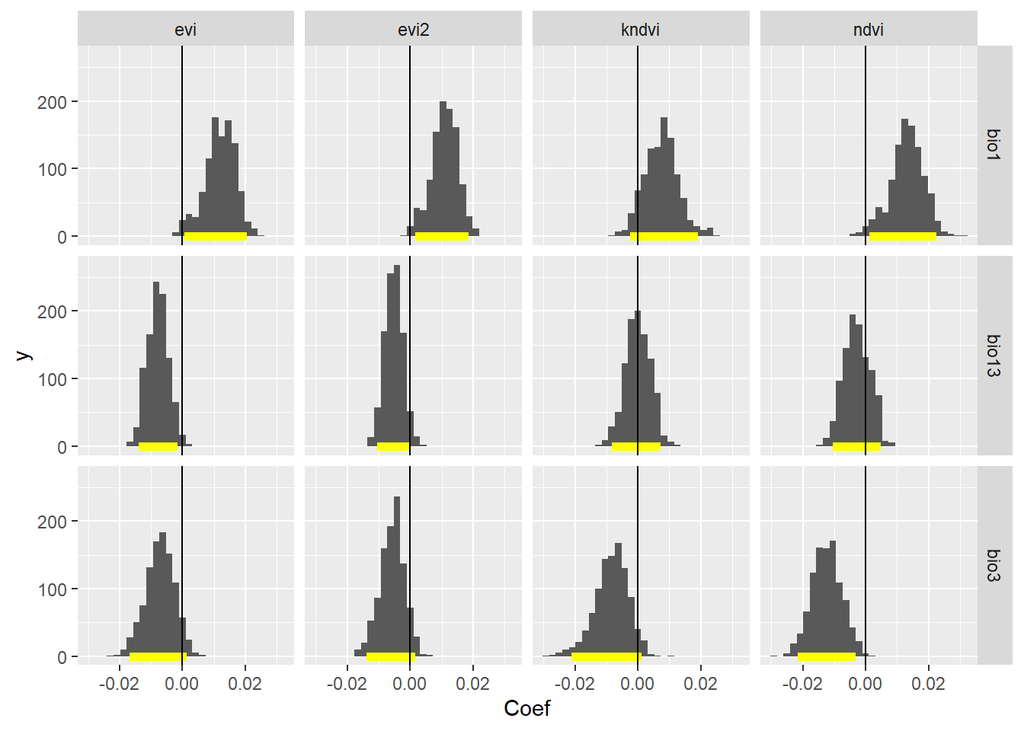

```r
cors2 %>%
  group_by(Index, Clim) %>%
  summarise(Q_2.5 = quantile(Coef, probs = 0.025), Q_97.5 = quantile(Coef, probs = 0.975)) -> quants

cors2 %>%
  ggplot(aes(x = Coef)) +
  geom_histogram() +
  facet_grid(Clim ~ Index) +
  geom_segment(data = quants, aes(x = Q_2.5, xend = Q_97.5, y = 0, yend = 0), color = "yellow", linewidth = 2)+
   geom_vline(xintercept = 0)
```

Получается, что evi, evi2 и ndvi положительно связаны с bio1 (температура). Индекс evi(и возможно evi2) отрицательно связан bio13 (Precipitation of Wettest Month). Наконец, ndvi отрицательно связан bio3 (Isothermality (BIO2/BIO7) (×100)).

Теперь смотрим на то, как это выглядит на первичных данных.

```r
Pl1 <-
evi %>%
  merge(clim_short) %>%
  ggplot(aes(x = bio1, y = evi.max)) +
  geom_point() +
  geom_smooth(method = "lm")
```

```r
Pl2 <-
evi %>%
  merge(clim_short) %>%
  ggplot(aes(x = bio3, y = evi.max)) +
  geom_point() +
  geom_smooth(method = "lm")
```

```r
Pl3 <-
evi %>%
  merge(clim_short) %>%
  ggplot(aes(x = bio13, y = evi.max)) +
  geom_point() +
  geom_smooth(method = "lm")
```

```r
Pl4 <-
evi2 %>%
  merge(clim_short) %>%
  ggplot(aes(x = bio1, y = evi2.max)) +
  geom_point() +
  geom_smooth(method = "lm")
```

```r
Pl5 <-
ndvi %>%
  merge(clim_short) %>%
  ggplot(aes(x = bio1, y = ndvi.max)) +
  geom_point() +
  geom_smooth(method = "lm")
```

```r
Pl6 <-

ndvi %>%
  merge(clim_short) %>%
  ggplot(aes(x = bio3, y = ndvi.max)) +
  geom_point() +
  geom_smooth(method = "lm")
```

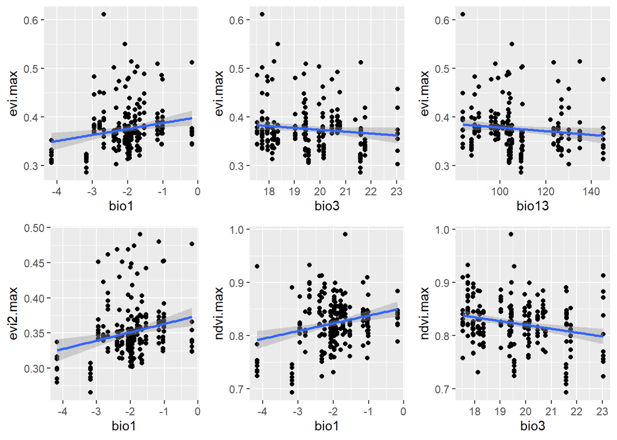

```r
library(cowplot)

plot_grid(Pl1, Pl2, Pl3, Pl4, Pl5, Pl6, ncol = 3)
```